# 1Graphics

# Basics of Time Series Objects

The aim of this section is to get you familiar with time series objects in R. Unlike the standard objects such as lists, data frames, matrices and vectors, time series objects have various attributes associated with them.

For this course, we will mainly be working with ts objects which are already in the base package. There are other types of time series objects such as xts and zoo, which have their own manipulation methods.

Load the Singapore Real GDP (seasonally adjusted) dataset.

```r
knitr::opts_chunk$set(message=FALSE)
```

```r
gdp <- read.csv("SGRGDP.csv")
head(gdp)
```

|  | Date | SG_RGDP |
| --- | --- | --- |
| 1 | 1975 Q1 | 7558.3 |
| 2 | 1975 Q2 | 7693.9 |
| 3 | 1975 Q3 | 7848.9 |
| 4 | 1975 Q4 | 7960.6 |
| 5 | 1976 Q1 | 8183.3 |
| 6 | 1976 Q2 | 8260.3 |

Notice that the left column contains the dates. While it is useful to note the start and end dates of the dataset, we can remove this column once we create the ts object.

```r
gdp.ts <- ts(gdp[,2], start=c(1975,1), end=c(2019,2), frequency=4)
gdp.ts
```

```
         Qtr1     Qtr2     Qtr3     Qtr4
1975   7558.3   7693.9   7848.9   7960.6
1976   8183.3   8260.3   8421.3   8509.6
1977   8698.2   8877.8   8967.5   9118.0
1978   9192.8   9411.4   9777.0  10044.2
1979  10070.6  10401.3  10591.0  11043.7
1980  11225.4  11450.8  11704.2  12002.0
1981  12358.6  12743.9  13021.7  13280.2
1982  13452.1  13665.7  13869.6  14074.0
1983  14441.5  14750.7  15055.7  15508.2
1984  15999.0  16190.3  16381.0  16438.6
1985  16629.3  16175.3  15993.3  15822.5
1986  15974.3  16182.3  16439.8  16861.2
1987  17272.6  17821.9  18443.7  18979.4
1988  19191.2  19965.4  20501.5  21037.4
```

[output cut: 31 more lines]

Hence, ts objects contain both the series and assign the period as an attribute. The start and end dates should be specified using a vector containing the year and period within the year. The latter should be specified as the number of intervals in a year depending on the sampling frequency (1 for annual, 4 for quarterly, 12 for monthly, 52 for weekly, etc.). In this example, we have data from 1975Q1 to 2019Q2. Note that most functions using ts objects require integer frequency, thus we should not specify weekly frequency as 365.25/7=52.18.

As with any analysis, we should always visualise the series first.

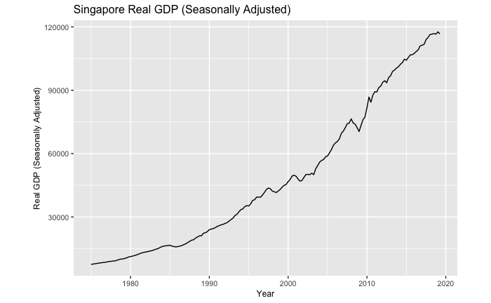

```r
library(gridExtra)
library(fpp2)
ptheme <- theme(aspect.ratio = 2/3, text=element_text(size=10),
                 axis.title = element_text(size=9))
autoplot(gdp.ts) + ylab("Real GDP (Seasonally Adjusted)") + xlab("Year") + ptheme + ggtitle("Singapore Real GDP (Seasonally Adjusted)")
```

The autoplot() function is versatile enough to recognise the type of object passed through it. In this example, it recognised the ts object and automatically generated a time series plot.

To change the sample range by date, use the window() function. Note that you do not need to specify the frequency again. To change the range using observation numbers, use the subset() function:

```r
window(gdp.ts, start=c(2000,1))
```

```
         Qtr1     Qtr2     Qtr3     Qtr4
2000  46748.5  47718.6  49373.8  49746.6
2001  49305.9  48028.9  46955.7  47263.4
2002  48698.9  50094.7  50127.0  50044.3
2003  50712.4  50016.0  52842.8  54340.6
2004  55957.2  56784.6  57171.5  58486.9
2005  58857.7  60385.6  61933.3  63995.8
2006  65052.4  65764.0  66983.8  69568.6
2007  70635.1  72273.5  74137.6  74475.8
2008  76430.2  74492.5  73932.3  72296.9
2009  70443.3  73399.2  76117.2  77348.9
2010  81708.5  86776.8  84303.8  87726.4
2011  89326.1  89176.0  91271.0  91957.7
2012  93742.9  94528.6  93538.4  95986.4
2013  96887.5  98913.5  99549.1 100515.1
2014 101180.2 102303.4 103170.1 104711.4
2015 104223.1 105523.5 106758.7 106819.6
2016 107455.4 108357.2 109127.1 111000.1
2017 111342.6 111752.7 113992.1 114996.7
2018 116379.6 116575.3 116817.0 116569.5
2019 117660.0 116676.8
```

```r
subset(gdp.ts, start=1, end=100)
```

```
        Qtr1    Qtr2    Qtr3    Qtr4
1975  7558.3  7693.9  7848.9  7960.6
1976  8183.3  8260.3  8421.3  8509.6
1977  8698.2  8877.8  8967.5  9118.0
1978  9192.8  9411.4  9777.0 10044.2
1979 10070.6 10401.3 10591.0 11043.7
1980 11225.4 11450.8 11704.2 12002.0
1981 12358.6 12743.9 13021.7 13280.2
1982 13452.1 13665.7 13869.6 14074.0
1983 14441.5 14750.7 15055.7 15508.2
1984 15999.0 16190.3 16381.0 16438.6
1985 16629.3 16175.3 15993.3 15822.5
1986 15974.3 16182.3 16439.8 16861.2
1987 17272.6 17821.9 18443.7 18979.4
1988 19191.2 19965.4 20501.5 21037.4
1989 21064.0 22263.9 22526.1 23039.3
1990 23989.0 24235.5 24513.6 24903.8
1991 25499.9 25857.6 26287.8 26497.7
1992 26961.0 27282.6 28024.7 28769.1
1993 29405.2 30672.9 31221.1 32444.1
1994 33435.5 33824.6 34882.3 35382.2
1995 35198.2 36238.9 37818.6 38160.3
1996 39401.2 39360.2 39363.4 40410.5
1997 41632.2 43021.9 43704.9 43344.8
1998 42219.5 41911.6 41558.9 42306.8
1999 43063.0 44150.8 44974.0 45358.3
```

Write your own code below to (1) load the US Real GDP (Seasonally Adjusted) series from a csv file “USRGDP.csv”, (2) create a ts object usgdp.ts; and (3) plot the series

```r
usgdp <- read.csv("USRGDP.csv")
usgdp
```

| Date | US_RGDP |
| --- | --- |
| 1947 Q1 | 2033.06 |
| 1947 Q2 | 2027.64 |
| 1947 Q3 | 2023.45 |
| 1947 Q4 | 2055.10 |
| 1948 Q1 | 2086.02 |
| 1948 Q2 | 2120.45 |
| 1948 Q3 | 2132.60 |
| 1948 Q4 | 2134.98 |
| 1949 Q1 | 2105.56 |
| 1949 Q2 | 2098.38 |

[output cut: 280 more lines]

```r
usgdp.ts <- ts(usgdp[,2], start=c(1947,1), end=c(2019,2), frequency=4)
usgdp.ts
```

```
         Qtr1     Qtr2     Qtr3     Qtr4
1947  2033.06  2027.64  2023.45  2055.10
1948  2086.02  2120.45  2132.60  2134.98
1949  2105.56  2098.38  2120.04  2102.25
1950  2184.87  2251.51  2338.51  2383.29
1951  2415.66  2457.52  2508.17  2513.69
1952  2540.55  2546.02  2564.40  2648.62
1953  2697.86  2718.71  2703.41  2662.48
1954  2649.76  2652.64  2682.60  2735.09
1955  2813.21  2858.99  2897.60  2914.99
1956  2903.67  2927.66  2925.03  2973.18
1957  2992.22  2985.66  3014.92  2983.73
1958  2906.27  2925.38  2993.07  3063.09
1959  3121.94  3192.38  3194.65  3203.76
1960  3275.76  3258.09  3274.03  3232.01
```

[output cut: 59 more lines]

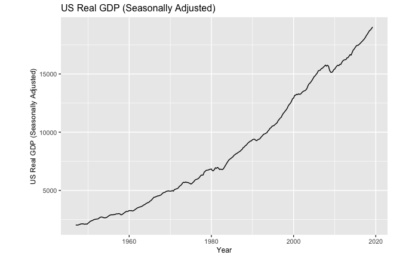

```r
autoplot(usgdp.ts) + ylab("US Real GDP (Seasonally Adjusted)") + xlab("Year") + ptheme + ggtitle("US Real GDP (Seasonally Adjusted)")
```

The following commands show how to create multivariate ts objects from single ts objects. Spot the differences in output.

```r
a <- ts.union(usgdp.ts,gdp.ts)
head(a)
```

```
        usgdp.ts gdp.ts
1947 Q1  2033.06     NA
1947 Q2  2027.64     NA
1947 Q3  2023.45     NA
1947 Q4  2055.10     NA
1948 Q1  2086.02     NA
1948 Q2  2120.45     NA
```

```r
b <- ts.intersect(usgdp.ts,gdp.ts)
head(b)
```

```
        usgdp.ts gdp.ts
1975 Q1  5548.16 7558.3
1975 Q2  5587.80 7693.9
1975 Q3  5683.44 7848.9
1975 Q4  5759.97 7960.6
1976 Q1  5889.50 8183.3
1976 Q2  5932.71 8260.3
```

```r
c <- ts(cbind(usgdp.ts,gdp.ts), start=start(usgdp.ts), end=end(usgdp.ts), frequency=4)
head(c)
```

```
        usgdp.ts gdp.ts
1947 Q1  2033.06     NA
1947 Q2  2027.64     NA
1947 Q3  2023.45     NA
1947 Q4  2055.10     NA
1948 Q1  2086.02     NA
1948 Q2  2120.45     NA
```

```r
head(ts.union(gdp.ts, lag(gdp.ts,-1), lag(gdp.ts,1)))
```

[output not shown]

## Reading & Plotting Multiple Time Series

Consider the arrivals dataset (contained in the fpp2 package). It contains data on quarterly visitor arrivals (in thousands) to Australia from Japan, New Zealand, UK and the US.

```r
head(arrivals)
```

```
         Japan     NZ     UK     US
1981 Q1 14.763 49.140 45.266 32.316
1981 Q2  9.321 87.467 19.886 23.721
1981 Q3 10.166 85.841 24.839 24.533
1981 Q4 19.509 61.882 52.264 33.438
1982 Q1 17.117 42.045 53.636 33.527
1982 Q2 10.617 63.081 34.802 28.366
```

Create the ts object and plot the series using the facets argument in the autoplot function.

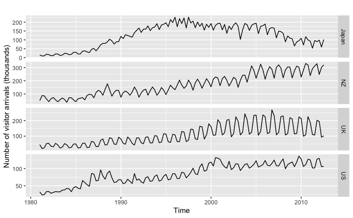

```r
arr.ts <- ts(arrivals, start=c(1981,1), end=c(2012,3), frequency=4)
autoplot(arr.ts, facets=TRUE) +
  ylab("Number of visitor arrivals (thousands)")
```

# Time Series Characteristics

The figure below shows the weekly economy passenger load on Ansett Airlines between Sydney and Melbourne.

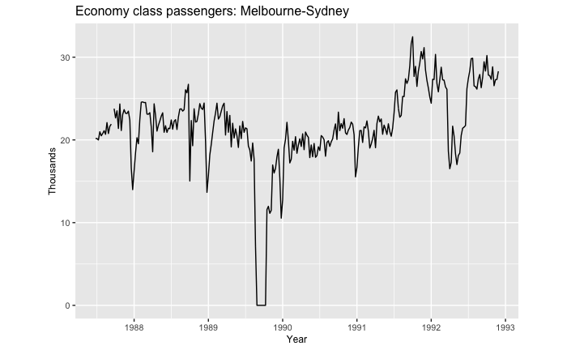

```r
autoplot(melsyd[,"Economy.Class"]) +
  ggtitle("Economy class passengers: Melbourne-Sydney") + ptheme +
  xlab("Year") +
  ylab("Thousands")
```

This series has many characteristics common to time series:

## Time Series wuth Seasonal Component

Explore the following Australian retail dataset. Select a series (one has been selected as the default) and note your observations on its characteristics.

```r
retaildata <- readxl::read_excel("retail.xlsx", skip=1)
head(retaildata)
```

| Series ID | A3349335T | A3349627V | A3349338X | A3349398A | A3349468W | A3349336V | A3349337W | A3349397X | A3349399C | A3349874C | A3349871W | A3349790V | A3349556W | A3349791W | A3349401C | A3349873A | A3349872X | A3349709X | A3349792X | A3349789K | A3349555V | A3349565X | A3349414R | A3349799R | A3349642T | A3349413L | A3349564W | A3349416V | A3349643V | … |
| --- | --- | --- | --- | --- | --- | --- | --- | --- | --- | --- | --- | --- | --- | --- | --- | --- | --- | --- | --- | --- | --- | --- | --- | --- | --- | --- | --- | --- | --- | --- |
| 1982-04-01 | 303.1 | 41.7 | 63.9 | 408.7 | 65.8 | 91.8 | 53.6 | 211.3 | 94.0 | 32.7 | 126.7 | 178.3 | 50.4 | 22.2 | 43.0 | 62.4 | 178.0 | 61.8 | 85.4 | 147.2 | 1250.2 | 257.9 | 17.3 | 34.9 | 310.2 | 58.2 | 55.8 | 59.1 | 173.1 | … |
| 1982-05-01 | 297.8 | 43.1 | 64.0 | 404.9 | 65.8 | 102.6 | 55.4 | 223.8 | 105.7 | 35.6 | 141.3 | 202.8 | 49.9 | 23.1 | 45.3 | 63.1 | 181.5 | 60.8 | 84.8 | 145.6 | 1300.0 | 257.4 | 18.1 | 34.6 | 310.1 | 62.0 | 58.4 | 59.2 | 179.5 | … |
| 1982-06-01 | 298.0 | 40.3 | 62.7 | 401.0 | 62.3 | 105.0 | 48.4 | 215.7 | 95.1 | 32.5 | 127.6 | 176.3 | 48.0 | 22.8 | 43.7 | 59.6 | 174.1 | 58.7 | 80.7 | 139.4 | 1234.2 | 261.2 | 18.1 | 34.6 | 313.9 | 53.8 | 53.7 | 59.8 | 167.3 | … |
| 1982-07-01 | 307.9 | 40.9 | 65.6 | 414.4 | 68.2 | 106.0 | 52.1 | 226.3 | 95.3 | 33.5 | 128.8 | 172.6 | 48.6 | 23.2 | 46.5 | 61.9 | 180.2 | 60.3 | 82.4 | 142.7 | 1265.0 | 266.1 | 18.9 | 35.2 | 320.2 | 57.9 | 56.9 | 59.8 | 174.5 | … |
| 1982-08-01 | 299.2 | 42.1 | 62.6 | 403.8 | 66.0 | 96.9 | 54.2 | 217.1 | 82.8 | 29.4 | 112.3 | 169.6 | 51.3 | 21.4 | 44.8 | 60.7 | 178.1 | 56.1 | 80.7 | 136.8 | 1217.6 | 247.2 | 19.0 | 33.8 | 300.1 | 59.2 | 56.7 | 62.2 | 178.1 | … |
| 1982-09-01 | 305.4 | 42.0 | 64.4 | 411.8 | 62.3 | 97.5 | 53.6 | 213.4 | 89.4 | 32.2 | 121.6 | 181.4 | 49.6 | 21.8 | 43.9 | 61.2 | 176.5 | 58.1 | 82.1 | 140.2 | 1244.9 | 262.4 | 18.4 | 35.4 | 316.2 | 57.1 | 58.9 | 63.6 | 179.6 | … |

```r
myts <- ts(retaildata[,"A3349873A"],
  frequency=12, start=c(1982,4))
myts
```

```
       Jan   Feb   Mar   Apr   May   Jun   Jul   Aug   Sep   Oct   Nov   Dec
1982                    62.4  63.1  59.6  61.9  60.7  61.2  62.1  68.3 104.0
1983  63.9  64.8  70.0  65.3  68.9  65.7  66.9  70.4  71.6  74.9  83.4 122.8
1984  69.0  71.8  74.9  70.2  76.6  68.7  70.1  74.6  70.6  80.5  87.2 121.3
1985  73.3  71.1  75.7  76.0  86.1  75.2  83.4  85.3  81.3  93.9 104.7 143.8
1986  88.5  85.2  86.2  92.4 100.9  90.1  96.1  97.2  96.8 107.7 110.9 161.0
1987  98.1  94.5  97.7  99.3 106.3  98.5 107.1 105.9 108.5 117.1 121.4 170.1
1988 109.0 110.7 115.5 105.7 114.3 107.5 108.8 109.6 118.4 125.5 151.8 232.4
1989 129.4 120.6 133.2 129.3 142.8 127.6 126.0 136.7 144.5 147.8 168.4 242.6
1990 141.2 139.8 152.1 135.8 148.0 135.8 138.7 144.8 139.9 151.6 163.9 215.8
1991 135.1 135.5 142.4 137.3 146.5 137.6 147.0 152.9 157.5 169.3 184.8 250.1
1992 164.4 169.8 171.0 167.5 173.2 150.8 160.9 164.5 173.6 182.7 196.9 255.5
1993 156.1 152.6 162.0 151.5 160.5 144.9 147.0 151.5 161.6 169.4 186.7 270.1
1994 159.6 161.0 171.3 152.6 159.5 157.4 156.9 169.6 186.2 206.3 198.3 269.5
1995 176.6 170.8 179.7 174.9 174.9 169.1 184.9 192.5 201.5 210.5 227.9 316.5
```

[output cut: 18 more lines]

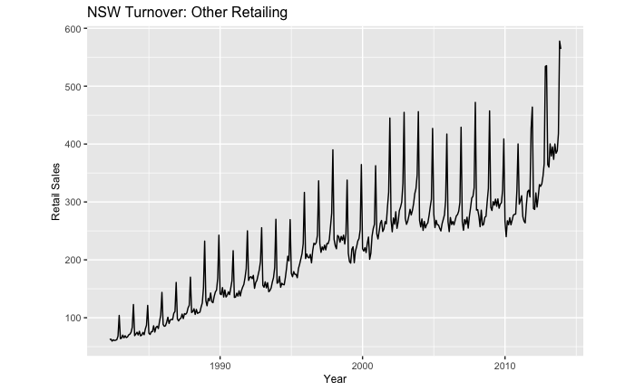

```r
autoplot(myts) +
  ggtitle("NSW Turnover: Other Retailing") + ptheme +
  xlab("Year") +
  ylab("Retail Sales")
```

## Seasonal Plots

These plots are useful for identifying seasonalities in the data. The observations are grouped by month and ordered by year within each month.

The series for New South Wales “other retailing” sales shows increasing variance over time, thus we apply the log transformation. Differencing the resulting series removes the trend. Can you explain the differences in the seasonal plots for the log-transformed and the log-differenced series?

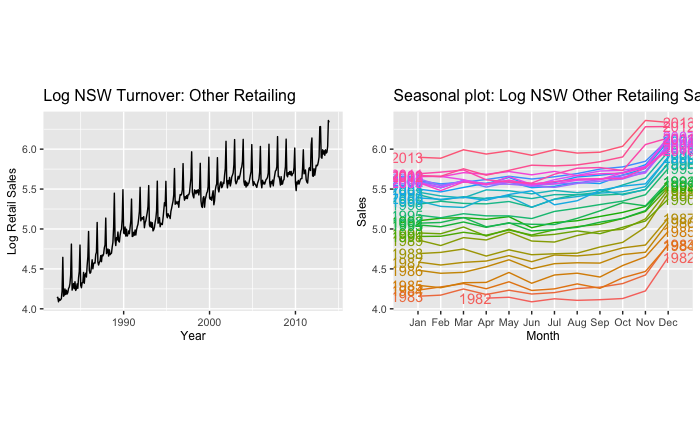

```r
myts <- ts(retaildata[,"A3349873A"], frequency=12, start=c(1982,4))

p1 <- autoplot(log(myts)) +
      ggtitle("Log NSW Turnover: Other Retailing") + ptheme +
      xlab("Year") +
      ylab("Log Retail Sales")

p2 <- ggseasonplot(log(myts), year.labels=TRUE, year.labels.left=TRUE) +
      ylab("Sales") + ptheme +
      ggtitle("Seasonal plot: Log NSW Other Retailing Sales")

grid.arrange(p1, p2, ncol=2)
```

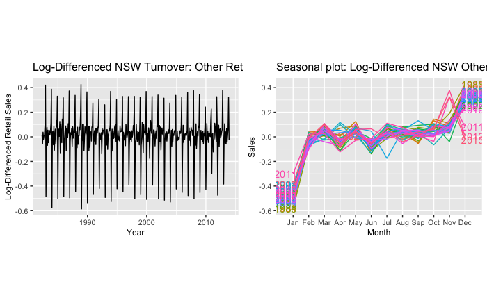

```r
p3 <- autoplot(diff(log(myts))) +
  ggtitle("Log-Differenced NSW Turnover: Other Retailing") + ptheme +
  xlab("Year") +
  ylab("Log-Differenced Retail Sales")

p4 <- ggseasonplot(diff(log(myts)), year.labels=TRUE, year.labels.left=TRUE) +
  ylab("Sales") + ptheme +
  ggtitle("Seasonal plot: Log-Differenced NSW Other Retailing Sales")

grid.arrange(p3, p4, ncol=2)
```

Another version of the seasonal plot uses polar coordinates:

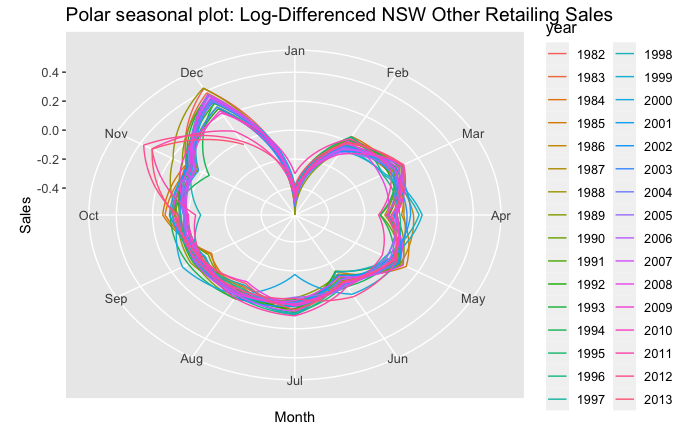

```r
ggseasonplot(diff(log(myts)),polar=TRUE) + theme(aspect.ratio = 4/5,text=element_text(size=12),
                 axis.title = element_text(size=11)) +
  ylab("Sales") +
  ggtitle("Polar seasonal plot: Log-Differenced NSW Other Retailing Sales")
```

Have a look at seasonal subseries plots, which are similar to seasonal plots except they clearly show any trend/changes within season. The horizontal lines indicate the average (across years) for each month.

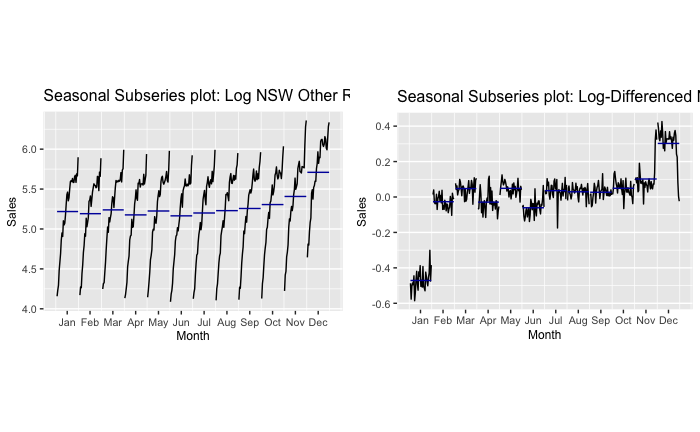

```r
p1 <- ggsubseriesplot(log(myts)) +
      ylab("Sales") + ptheme +
      ggtitle("Seasonal Subseries plot: Log NSW Other Retailing Sales")

p2 <- ggsubseriesplot(diff(log(myts))) +
      ylab("Sales") + ptheme +
      ggtitle("Seasonal Subseries plot: Log-Differenced NSW Other Retailing Sales")

grid.arrange(p1,p2,ncol=2)
```

Questions:

1. Can you explain any differences between the seasonal subseries plots of the log-transformed and log-differenced series?
2. From both the seasonal and seasonal subseries plots, what can you conclude about the presence of seasonalities?
3. What are the assumptions made in detecting the presence of seasonalities?
4. What are the possible reasons for the detected seasonalities?

## Exercise 1

Choose another Australian retail series “A3349563V”, perform appropriate transformations and explore the seasonal plots.

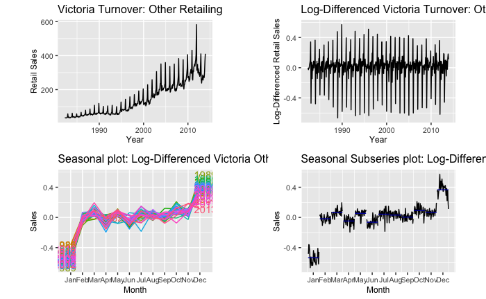

```r
#Write your code here
myts_2 <- ts(retaildata[,"A3349563V"],
  frequency=12, start=c(1982,4))

p1 <- autoplot(myts_2) +
  ggtitle("Victoria Turnover: Other Retailing") + ptheme +
  xlab("Year") +
  ylab("Retail Sales")

p2 <- autoplot(diff(log(myts_2))) +
      ggtitle("Log-Differenced Victoria Turnover: Other Retailing") + ptheme +
      xlab("Year") +
      ylab("Log-Differenced Retail Sales")

p3 <- ggseasonplot(diff(log(myts_2)), year.labels=TRUE, year.labels.left=TRUE) +
      ylab("Sales") + ptheme +
      ggtitle("Seasonal plot: Log-Differenced Victoria Other Retailing Sales")

p4 <- ggsubseriesplot(diff(log(myts_2))) +
      ylab("Sales") + ptheme +
      ggtitle("Seasonal Subseries plot: Log-Differenced Victoria Other Retailing Sales")

grid.arrange(p1,p2,p3,p4,ncol=2)
```

## Scatter Plots

Scatter plots are useful to visualise relationships between time series as well as the correlations over time within individual time series. The following plots Singapore Real GDP vs. US Real GDP, pooling across all observations from different periods.

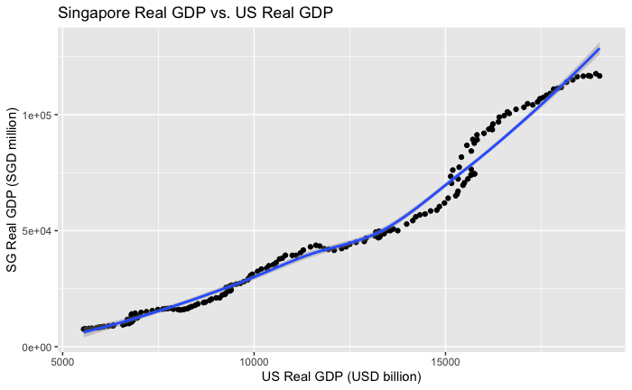

```r
qplot(usgdp.ts, gdp.ts, data=as.data.frame(b)) +
  ylab("SG Real GDP (SGD million)") + xlab("US Real GDP (USD billion)")+
  ggtitle("Singapore Real GDP vs. US Real GDP")+
  geom_smooth(method = loess)
```

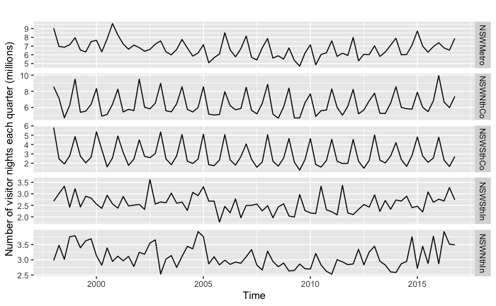

```r
autoplot(visnights[,1:5], facets=TRUE) +
  ylab("Number of visitor nights each quarter (millions)")
```

The scatterplot matrix below shows the pairwise relationships between series. The variable on the y-axis is given by the variable name in the **row**, while the variable on the x-axis is given by the variable name in the **column**.

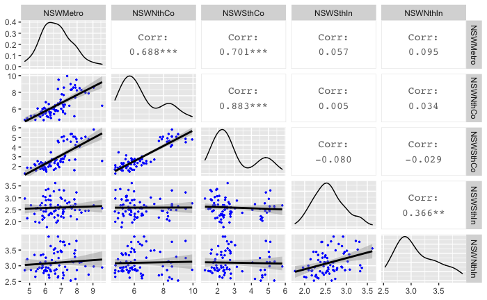

```r
#install this package in your console if you do not have it yet
library(GGally)
ggpairs(as.data.frame(visnights[,1:5]), lower = list(continuous = wrap("smooth", size=0.5,color="blue")))
```

Questions:

1. Are there any strong correlations between regions?
2. Can you spot an outlier corresponding to the 2000 Sydney Olympics?

For more details on how you can customise your scatter matrices, visit [this blog](https://www.blopig.com/blog/2019/06/a-brief-introduction-to-ggpairs/).

Explore the correlations for Australian retail sales within the same category but between different regions, i.e. “A3349873A”,“A3349563V”,“A3349881A”,“A3349577J”,“A3349908R”.

```r
ggpairs(as.data.frame(retaildata[,c("A3349873A","A3349563V","A3349881A","A3349577J","A3349908R")]), lower = list(continuous = wrap("smooth", size=0.5,color="red")))
```

[output not shown]

## Autocorrelation

Recall that the autocorrelation function (ACF) is
$$\rho_k = \frac{Cov(Y_t,Y_{t-k})}{\sqrt{Var(Y_t)}\sqrt{Var(Y_{t-k})}}$$
. The sample counterpart is
$$\hat{\rho}_k = \frac{\sum_{t=k+1}^T (Y_t-\bar{Y})(Y_{t-k}-\bar{Y})}{\sum_{t=1}^T (Y_t-\bar{Y})^2}$$
where $T$ is the length of the time series.

Often, we plot the sample ACF or *correlogram*.

```r
ggAcf(diff(log(gdp.ts))) + ggtitle("Correlogram for SG Real GDP Growth")
```

[output not shown]

Observe the ACF of a trending series. Can you explain the pattern?

```r
ggAcf(log(gdp.ts)) + ggtitle("Correlogram for Log SG Real GDP")
```

[output not shown]

Also observe the ACF of a de-trended series with seasonality.

```r
ggAcf(diff(log(myts))) + ggtitle("Correlogram for Log-Differenced SG Real GDP Growth")
```

[output not shown]

Question: What causes the sharp spikes at lags 12 and 24?

## Exercise 2

```r
myts_2 <- ts(retaildata[,"A3349563V"], frequency=12, start=c(1982,4))

p1 <- ggAcf(log(myts_2)) +theme(text=element_text(size=11))+ ggtitle("Log Victoria Other Retailing Sales")
p2 <- ggAcf(diff(log(myts_2))) + theme(text=element_text(size=10)) + ggtitle("Log-Differenced Victoria Other Retailing Sales")

grid.arrange(p1, p2, ncol=2)
```

[output not shown]

# White Noise

The white noise process describes series which have purely random fluctuations. Therefore, the autocorrelations should be zero regardless of the lag interval. While we do not observe the true autocorrelations, we should expect the sample autocorrelations to be statistically insignificant and close to zero. In fact, 95% of the spikes in the sample ACF should lie within $\pm \frac{1.96}{\sqrt{T}}$.

```r
set.seed(30)
y <- ts(rnorm(50))
p1 <- autoplot(y) + ggtitle("White noise") + ptheme
p2 <- ggAcf(y)+ptheme+ggtitle("")
grid.arrange(p1,p2,ncol=2)
```

[output not shown]